# Overview of your figures and data

mdijkstra

2020-10-21

> Please beware that browsers other than Chrome may not show the right font.

# 1 Figures

## 1.1 Industriële productie en detailhandel

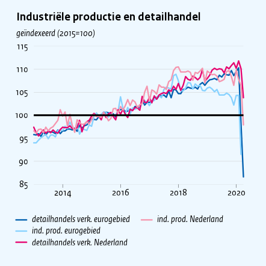

Loonkostensubsidies voor arbeidstijdverkorting hebben de stijging van de werkloosheid in het eurogebied en in Nederland sterk beperkt.

## 1.2 Werkloosheid

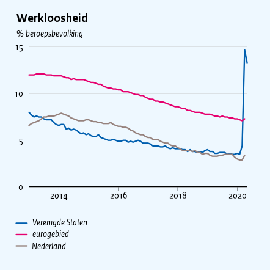

## 1.3 Bbp-ontwikkeling per kwartaal

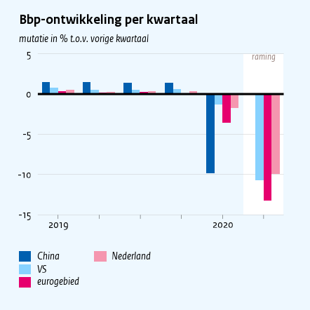

Bron: CBS, CPB, Eurostat, Chinees statistisch bureau.

## 1.4 Mondiale bbp-ontwikkeling

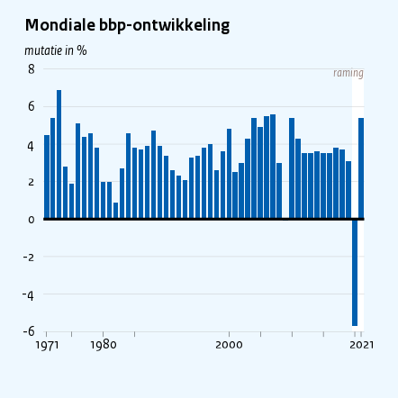

## 1.5 Weekmutatie balanstotaal ECB en FED

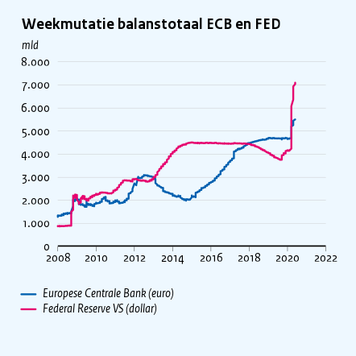

Bron: Federal Reserve, ECB en Euronext.

## 1.6 Ontwikkeling AEX-index en Dow Jones

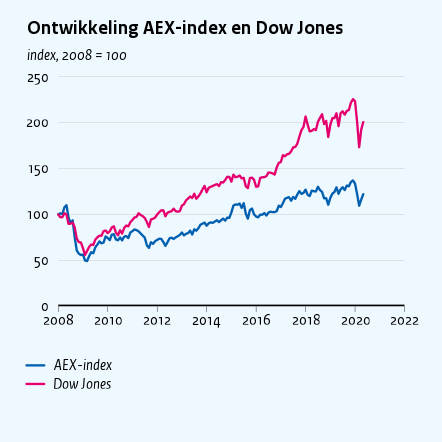

## 1.7 Wereldhandelsvolume per kwartaal

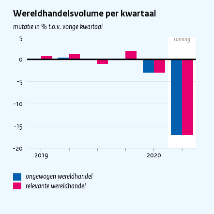

Bron: CPB en IATA.

## 1.8 IATA baseline Covid-19 scenario

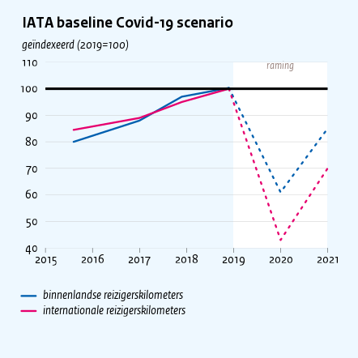

## 1.9 Beroeps- en niet-beroepsbevolking

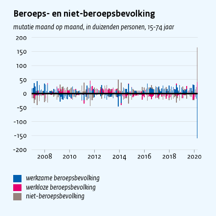

Bron: CBS.

## 1.10 Werkverliezers

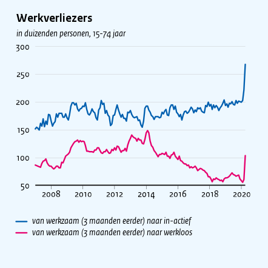

## 1.11 Bruto binnenlands product

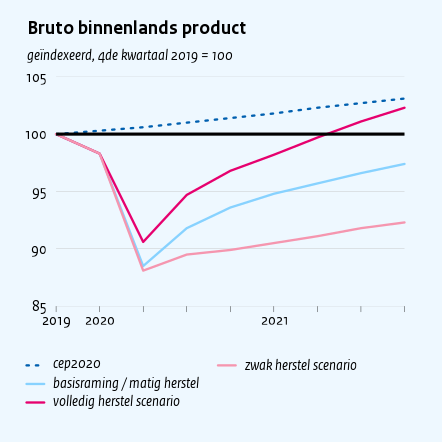

## 1.12 Bruto binnenlands product

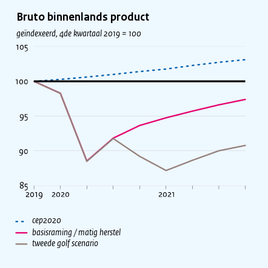

## 1.13 Groeibijdragen bestedingen (a)

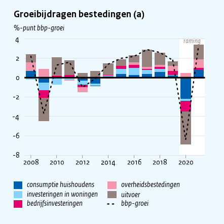

De finale en gecumuleerde intermediaire invoer zijn in mindering gebracht op de bestedingscategorieën. Bron: CBS en CPB.

## 1.14 Ontwikkeling bestedingen en bbp

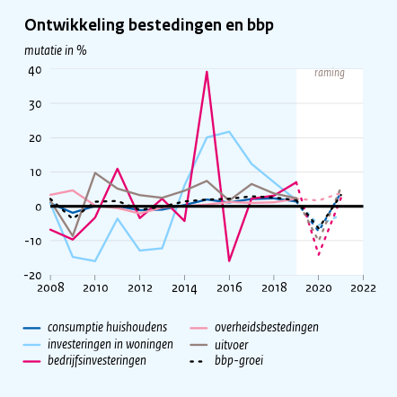

## 1.15 Saldo overheidsbegroting

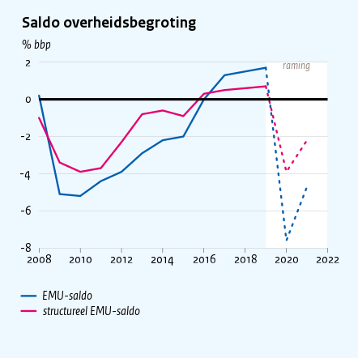

Bron: CBS en CPB.

## 1.16 Overheidsschuld

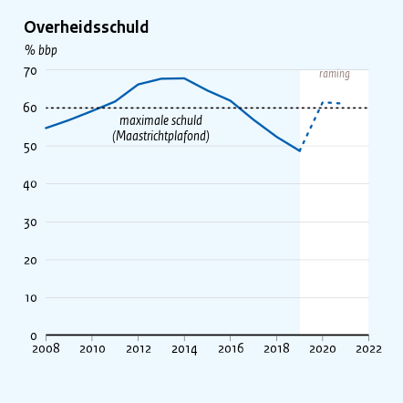

## 1.17 Steunpakketten

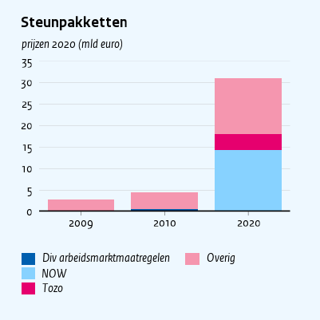

Bron: CPB inschatting voor NL, voor de overige landen EC (alle maatregelen tot eind april exclusief belastinguitstel)

## 1.18 Europese steunpakketten

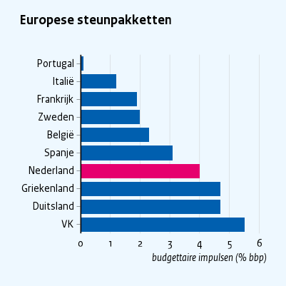

## 1.19 Economische groei in Nederland

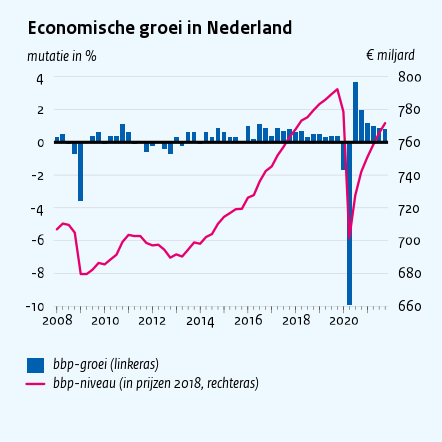

# 2 Customize on this report

This section explains how to quickly customize this report by changing the value of some parameters. You can find or add the parameters in the meta-tab of your xlsx-file (`ext/report/kmev2021/james-kmev2021.xlsx`) in the column which has `type = report`. For example, if you don’t want the current section in your report, you can disable it by setting parameter `report_include_james_appendix = n`.

A tip to quickly test text without repeatedly recreating your figures is setting `create = n` in your globals-tab. If you don’t specify the `create` parameter in your meta-tab, no report and no figures will be created. So, setting `create = y` only for your report (in the meta-tab), makes sure, only the report itself is generated (*i.e.* without the figures). This makes it possible to change/update the text and watch the resulting report quicly. In the end, *i.e.* before creating the final report, you can put the original settings back and then generate the full report.

## 2.1 Choose output format (html, pdf)

Please use `report_format` to indicate which report output formats you want. The default is `html`. You can choose from:

1. document options
- html
- pdf
- word [under development; this may not work]
2. presentation options
- ioslides [under development; this may not work]
- slidy [under development; this may not work]
- powerpoint [under development; this may not work]
- beamer [under development; this may not work]

You can choose one or more options at the same time (*e.g.* `report_format = html, pdf`).

## 2.2 Edit the front page

In the ‘report column’ of your xlsx-file, you can set the parameters `title`, `author` and `date` to customize the title, author and date that are shown at the start of this report. For example, `author = prof.dr.ir. Great Me` will update the author as given here.

## 2.3 Customize the text in this report

This section explains the simplest way to create your own custom report from Excel. First create a new tab in `ext/report/kmev2021/james-kmev2021.xlsx` for your custom text. Let’s assume the name of this new tab is `my-custom-report`. Now add `tab = my-custom-report` to the meta-tab in your xlsx, in the column which has `type = report`.

The text in this column will now appear in your report instead of the default text and figures.

### 2.3.2 Adding custom text to your report

The text you type in the Excel-tab may be accross multiple lines. You can put each line in a new cell. However, please use the first column only.

### 2.3.3 Style your text (headers, markup, etc.)

This [good cheat sheet](https://github.com/adam-p/markdown-here/wiki/Markdown-Cheatsheet) explains how to add headers, lists, and make your text bold/italic, etc.

### 2.3.4 Plotting an individual figure

```r
plot("path/to/james-kmev2021.xlxs", id = "1a")
```

## 2.4 Troubleshooting

In case of odd behaviour, you can manually inspect the generated Rmd- and md-files of this report in `/Users/mdijkstra/Dropbox/cpb/git/james/./generated/report`. The subdirectory `generated` of this directory contains the separate figures in this report. Please beware, don’t edit the generated Rmd- or md-files as they are overwritten each time again.

## 2.5 More details

Please see /Users/mdijkstra/Dropbox/cpb/git/james/james-dev-2020-10-13-manual.html for further details on how to improve your report and figures.

James (version `dev-2020-10-13`) finished this report at 2020-10-21 12:09:31. Time used: 23.3 s.